# Risk Factor Analysis

## Outcome Variable

**Outcome Variable:** dead

## Predictor Variables

**Intervention Variable:** ever_stunted06

**Adjustment Set:**

unadjusted

## Stratifying Variables

The analysis was stratified on these variable(s):

- studyid
- country

## Data Summary

| studyid | country | ever_stunted06 | dead | n_cell | n |
| --- | --- | --- | --- | --- | --- |
| Burkina Faso Zn | BURKINA FASO | 0 | 0 | 297 | 338 |
| Burkina Faso Zn | BURKINA FASO | 0 | 1 | 2 | 338 |
| Burkina Faso Zn | BURKINA FASO | 1 | 0 | 39 | 338 |
| Burkina Faso Zn | BURKINA FASO | 1 | 1 | 0 | 338 |
| EE | PAKISTAN | 0 | 0 | 93 | 379 |
| EE | PAKISTAN | 0 | 1 | 0 | 379 |
| EE | PAKISTAN | 1 | 0 | 282 | 379 |
| EE | PAKISTAN | 1 | 1 | 4 | 379 |
| GMS-Nepal | NEPAL | 0 | 0 | 473 | 698 |
| GMS-Nepal | NEPAL | 0 | 1 | 3 | 698 |
| GMS-Nepal | NEPAL | 1 | 0 | 217 | 698 |
| GMS-Nepal | NEPAL | 1 | 1 | 5 | 698 |
| iLiNS-DOSE | MALAWI | 0 | 0 | 1194 | 1813 |
| iLiNS-DOSE | MALAWI | 0 | 1 | 73 | 1813 |
| iLiNS-DOSE | MALAWI | 1 | 0 | 505 | 1813 |
| iLiNS-DOSE | MALAWI | 1 | 1 | 41 | 1813 |
| iLiNS-DYAD-M | MALAWI | 0 | 0 | 835 | 1191 |
| iLiNS-DYAD-M | MALAWI | 0 | 1 | 23 | 1191 |
| iLiNS-DYAD-M | MALAWI | 1 | 0 | 317 | 1191 |
| iLiNS-DYAD-M | MALAWI | 1 | 1 | 16 | 1191 |
| JiVitA-3 | BANGLADESH | 0 | 0 | 15085 | 27197 |
| JiVitA-3 | BANGLADESH | 0 | 1 | 262 | 27197 |
| JiVitA-3 | BANGLADESH | 1 | 0 | 11311 | 27197 |
| JiVitA-3 | BANGLADESH | 1 | 1 | 539 | 27197 |
| JiVitA-4 | BANGLADESH | 0 | 0 | 3217 | 5270 |
| JiVitA-4 | BANGLADESH | 0 | 1 | 20 | 5270 |
| JiVitA-4 | BANGLADESH | 1 | 0 | 2006 | 5270 |
| JiVitA-4 | BANGLADESH | 1 | 1 | 27 | 5270 |
| Keneba | GAMBIA | 0 | 0 | 1669 | 2479 |
| Keneba | GAMBIA | 0 | 1 | 25 | 2479 |
| Keneba | GAMBIA | 1 | 0 | 751 | 2479 |
| Keneba | GAMBIA | 1 | 1 | 34 | 2479 |
| MAL-ED | BANGLADESH | 0 | 0 | 167 | 265 |
| MAL-ED | BANGLADESH | 0 | 1 | 0 | 265 |
| MAL-ED | BANGLADESH | 1 | 0 | 95 | 265 |
| MAL-ED | BANGLADESH | 1 | 1 | 3 | 265 |
| MAL-ED | INDIA | 0 | 0 | 158 | 251 |
| MAL-ED | INDIA | 0 | 1 | 1 | 251 |
| MAL-ED | INDIA | 1 | 0 | 91 | 251 |
| MAL-ED | INDIA | 1 | 1 | 1 | 251 |
| MAL-ED | PERU | 0 | 0 | 171 | 303 |
| MAL-ED | PERU | 0 | 1 | 1 | 303 |
| MAL-ED | PERU | 1 | 0 | 130 | 303 |
| MAL-ED | PERU | 1 | 1 | 1 | 303 |
| MAL-ED | SOUTH AFRICA | 0 | 0 | 194 | 314 |
| MAL-ED | SOUTH AFRICA | 0 | 1 | 0 | 314 |
| MAL-ED | SOUTH AFRICA | 1 | 0 | 119 | 314 |
| MAL-ED | SOUTH AFRICA | 1 | 1 | 1 | 314 |
| MAL-ED | TANZANIA, UNITED REPUBLIC OF | 0 | 0 | 148 | 262 |
| MAL-ED | TANZANIA, UNITED REPUBLIC OF | 0 | 1 | 1 | 262 |
| MAL-ED | TANZANIA, UNITED REPUBLIC OF | 1 | 0 | 111 | 262 |
| MAL-ED | TANZANIA, UNITED REPUBLIC OF | 1 | 1 | 2 | 262 |
| PROVIDE | BANGLADESH | 0 | 0 | 527 | 700 |
| PROVIDE | BANGLADESH | 0 | 1 | 4 | 700 |
| PROVIDE | BANGLADESH | 1 | 0 | 169 | 700 |
| PROVIDE | BANGLADESH | 1 | 1 | 0 | 700 |
| SAS-CompFeed | INDIA | 0 | 0 | 853 | 1532 |
| SAS-CompFeed | INDIA | 0 | 1 | 14 | 1532 |
| SAS-CompFeed | INDIA | 1 | 0 | 629 | 1532 |
| SAS-CompFeed | INDIA | 1 | 1 | 36 | 1532 |
| SAS-FoodSuppl | INDIA | 0 | 0 | 226 | 418 |
| SAS-FoodSuppl | INDIA | 0 | 1 | 2 | 418 |
| SAS-FoodSuppl | INDIA | 1 | 0 | 186 | 418 |
| SAS-FoodSuppl | INDIA | 1 | 1 | 4 | 418 |
| TanzaniaChild2 | TANZANIA, UNITED REPUBLIC OF | 0 | 0 | 1905 | 2396 |
| TanzaniaChild2 | TANZANIA, UNITED REPUBLIC OF | 0 | 1 | 1 | 2396 |
| TanzaniaChild2 | TANZANIA, UNITED REPUBLIC OF | 1 | 0 | 490 | 2396 |
| TanzaniaChild2 | TANZANIA, UNITED REPUBLIC OF | 1 | 1 | 0 | 2396 |
| VITAMIN-A | INDIA | 0 | 0 | 2265 | 3898 |
| VITAMIN-A | INDIA | 0 | 1 | 29 | 3898 |
| VITAMIN-A | INDIA | 1 | 0 | 1556 | 3898 |
| VITAMIN-A | INDIA | 1 | 1 | 48 | 3898 |
| ZVITAMBO | ZIMBABWE | 0 | 0 | 9428 | 14060 |
| ZVITAMBO | ZIMBABWE | 0 | 1 | 623 | 14060 |
| ZVITAMBO | ZIMBABWE | 1 | 0 | 3527 | 14060 |
| ZVITAMBO | ZIMBABWE | 1 | 1 | 482 | 14060 |

The following strata were considered:

- studyid: Burkina Faso Zn, country: BURKINA FASO
- studyid: EE, country: PAKISTAN
- studyid: GMS-Nepal, country: NEPAL
- studyid: iLiNS-DOSE, country: MALAWI
- studyid: iLiNS-DYAD-M, country: MALAWI
- studyid: JiVitA-3, country: BANGLADESH
- studyid: JiVitA-4, country: BANGLADESH
- studyid: Keneba, country: GAMBIA
- studyid: MAL-ED, country: BANGLADESH
- studyid: MAL-ED, country: INDIA
- studyid: MAL-ED, country: PERU
- studyid: MAL-ED, country: SOUTH AFRICA
- studyid: MAL-ED, country: TANZANIA, UNITED REPUBLIC OF
- studyid: PROVIDE, country: BANGLADESH
- studyid: SAS-CompFeed, country: INDIA
- studyid: SAS-FoodSuppl, country: INDIA
- studyid: TanzaniaChild2, country: TANZANIA, UNITED REPUBLIC OF
- studyid: VITAMIN-A, country: INDIA
- studyid: ZVITAMBO, country: ZIMBABWE

### Dropped Strata

Some strata were dropped due to rare outcomes:

- studyid: Burkina Faso Zn, country: BURKINA FASO
- studyid: EE, country: PAKISTAN
- studyid: GMS-Nepal, country: NEPAL
- studyid: MAL-ED, country: BANGLADESH
- studyid: MAL-ED, country: INDIA
- studyid: MAL-ED, country: PERU
- studyid: MAL-ED, country: SOUTH AFRICA
- studyid: MAL-ED, country: TANZANIA, UNITED REPUBLIC OF
- studyid: PROVIDE, country: BANGLADESH
- studyid: SAS-FoodSuppl, country: INDIA
- studyid: TanzaniaChild2, country: TANZANIA, UNITED REPUBLIC OF

## Methods Detail

We’re interested in the causal parameters $E[Y_a]$ for all values of $a \in \mathcal{A}$. These parameters represent the mean outcome if, possibly contrary to fact, we intervened to set all units to have $A=a$. Under the randomization and positivity assumptions, these are identified by the statistical parameters $\psi_a=E_W[E_{Y|A,W}(Y|A=a,W)]$. In addition, we’re interested in the mean of $Y$, $E[Y]$ under no intervention (the observed mean). We will estimate these parameters by using SuperLearner to fit the relevant likelihood factors – $E_{Y|A,W}(Y|A=a,W)$ and $p(A=a|W)$, and then updating our likelihood fit using a joint TMLE.

For unadjusted analyses ($W=\{\}$), initial likelihoods were estimated using Lrnr_glm to estimate the simple $E(Y|A)$ and Lrnr_mean to estimate $p(A)$. For adjusted analyses, a small library containing Lrnr_glmnet, Lrnr_xgboost, and Lrnr_mean was used.

Having estimated these parameters, we will then use the delta method to estimate relative risks and attributable risks relative to a prespecified baseline level of $A$.

# Results Detail

## Results Plots

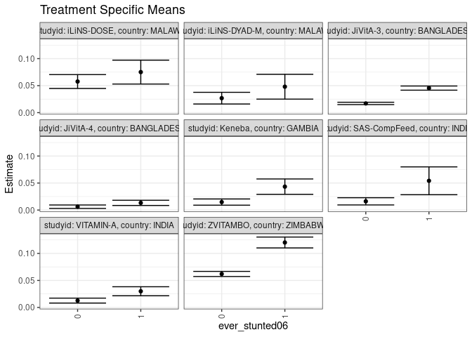

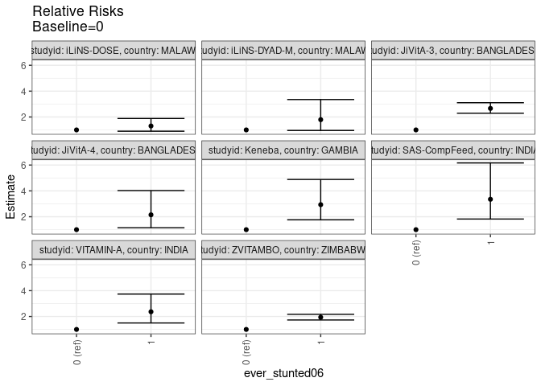

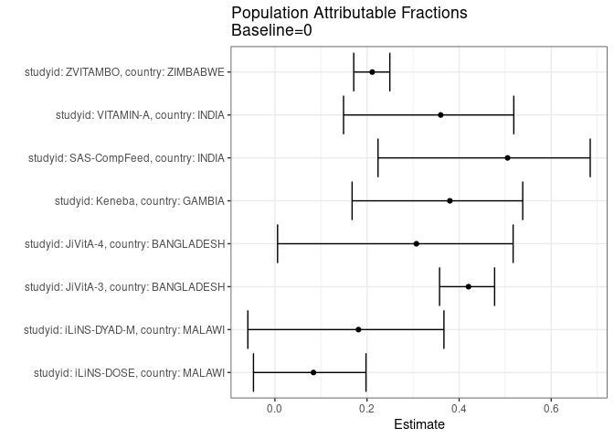

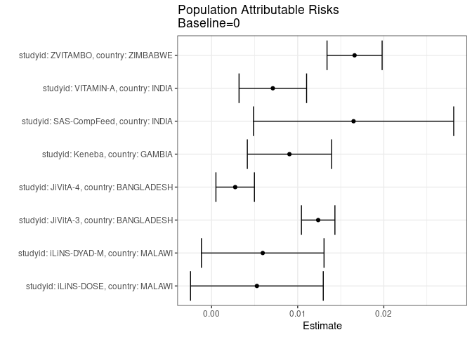

## Results Table

### Parameter: TSM

| studyid | country | intervention_level | baseline_level | estimate | ci_lower | ci_upper |
| --- | --- | --- | --- | --- | --- | --- |
| iLiNS-DOSE | MALAWI | 0 | NA | 0.0576164 | 0.0447823 | 0.0704506 |
| iLiNS-DOSE | MALAWI | 1 | NA | 0.0750916 | 0.0529802 | 0.0972030 |
| iLiNS-DYAD-M | MALAWI | 0 | NA | 0.0268065 | 0.0159945 | 0.0376185 |
| iLiNS-DYAD-M | MALAWI | 1 | NA | 0.0480480 | 0.0250679 | 0.0710282 |
| JiVitA-3 | BANGLADESH | 0 | NA | 0.0170717 | 0.0149129 | 0.0192306 |
| JiVitA-3 | BANGLADESH | 1 | NA | 0.0454852 | 0.0416321 | 0.0493383 |
| JiVitA-4 | BANGLADESH | 0 | NA | 0.0061786 | 0.0030109 | 0.0093462 |
| JiVitA-4 | BANGLADESH | 1 | NA | 0.0132809 | 0.0084382 | 0.0181236 |
| Keneba | GAMBIA | 0 | NA | 0.0147580 | 0.0090146 | 0.0205013 |
| Keneba | GAMBIA | 1 | NA | 0.0433121 | 0.0290695 | 0.0575547 |
| SAS-CompFeed | INDIA | 0 | NA | 0.0161476 | 0.0094501 | 0.0228452 |
| SAS-CompFeed | INDIA | 1 | NA | 0.0541353 | 0.0283755 | 0.0798952 |
| VITAMIN-A | INDIA | 0 | NA | 0.0126417 | 0.0080692 | 0.0172141 |
| VITAMIN-A | INDIA | 1 | NA | 0.0299252 | 0.0215860 | 0.0382644 |
| ZVITAMBO | ZIMBABWE | 0 | NA | 0.0619839 | 0.0572697 | 0.0666980 |
| ZVITAMBO | ZIMBABWE | 1 | NA | 0.1202295 | 0.1101617 | 0.1302973 |

### Parameter: E(Y)

| studyid | country | intervention_level | baseline_level | estimate | ci_lower | ci_upper |
| --- | --- | --- | --- | --- | --- | --- |
| iLiNS-DOSE | MALAWI | NA | NA | 0.0628792 | 0.0517023 | 0.0740561 |
| iLiNS-DYAD-M | MALAWI | NA | NA | 0.0327456 | 0.0226340 | 0.0428572 |
| JiVitA-3 | BANGLADESH | NA | NA | 0.0294518 | 0.0273600 | 0.0315436 |
| JiVitA-4 | BANGLADESH | NA | NA | 0.0089184 | 0.0062077 | 0.0116291 |
| Keneba | GAMBIA | NA | NA | 0.0237999 | 0.0177985 | 0.0298013 |
| SAS-CompFeed | INDIA | NA | NA | 0.0326371 | 0.0205116 | 0.0447625 |
| VITAMIN-A | INDIA | NA | NA | 0.0197537 | 0.0153848 | 0.0241226 |
| ZVITAMBO | ZIMBABWE | NA | NA | 0.0785917 | 0.0741435 | 0.0830400 |

### Parameter: RR

| studyid | country | intervention_level | baseline_level | estimate | ci_lower | ci_upper |
| --- | --- | --- | --- | --- | --- | --- |
| iLiNS-DOSE | MALAWI | 0 | 0 | 1.000000 | 1.0000000 | 1.000000 |
| iLiNS-DOSE | MALAWI | 1 | 0 | 1.303302 | 0.9009364 | 1.885366 |
| iLiNS-DYAD-M | MALAWI | 0 | 0 | 1.000000 | 1.0000000 | 1.000000 |
| iLiNS-DYAD-M | MALAWI | 1 | 0 | 1.792401 | 0.9587884 | 3.350793 |
| JiVitA-3 | BANGLADESH | 0 | 0 | 1.000000 | 1.0000000 | 1.000000 |
| JiVitA-3 | BANGLADESH | 1 | 0 | 2.664358 | 2.2874140 | 3.103419 |
| JiVitA-4 | BANGLADESH | 0 | 0 | 1.000000 | 1.0000000 | 1.000000 |
| JiVitA-4 | BANGLADESH | 1 | 0 | 2.149508 | 1.1476063 | 4.026106 |
| Keneba | GAMBIA | 0 | 0 | 1.000000 | 1.0000000 | 1.000000 |
| Keneba | GAMBIA | 1 | 0 | 2.934828 | 1.7632402 | 4.884879 |
| SAS-CompFeed | INDIA | 0 | 0 | 1.000000 | 1.0000000 | 1.000000 |
| SAS-CompFeed | INDIA | 1 | 0 | 3.352524 | 1.8229978 | 6.165349 |
| VITAMIN-A | INDIA | 0 | 0 | 1.000000 | 1.0000000 | 1.000000 |
| VITAMIN-A | INDIA | 1 | 0 | 2.367186 | 1.4994633 | 3.737049 |
| ZVITAMBO | ZIMBABWE | 0 | 0 | 1.000000 | 1.0000000 | 1.000000 |
| ZVITAMBO | ZIMBABWE | 1 | 0 | 1.939690 | 1.7322250 | 2.172001 |

### Parameter: PAR

| studyid | country | intervention_level | baseline_level | estimate | ci_lower | ci_upper |
| --- | --- | --- | --- | --- | --- | --- |
| iLiNS-DOSE | MALAWI | 0 | NA | 0.0052628 | -0.0024455 | 0.0129711 |
| iLiNS-DYAD-M | MALAWI | 0 | NA | 0.0059391 | -0.0011824 | 0.0130605 |
| JiVitA-3 | BANGLADESH | 0 | NA | 0.0123800 | 0.0104352 | 0.0143249 |
| JiVitA-4 | BANGLADESH | 0 | NA | 0.0027398 | 0.0005043 | 0.0049754 |
| Keneba | GAMBIA | 0 | NA | 0.0090420 | 0.0041509 | 0.0139330 |
| SAS-CompFeed | INDIA | 0 | NA | 0.0164894 | 0.0048572 | 0.0281217 |
| VITAMIN-A | INDIA | 0 | NA | 0.0071120 | 0.0031895 | 0.0110346 |
| ZVITAMBO | ZIMBABWE | 0 | NA | 0.0166079 | 0.0134084 | 0.0198073 |

### Parameter: PAF

| studyid | country | intervention_level | baseline_level | estimate | ci_lower | ci_upper |
| --- | --- | --- | --- | --- | --- | --- |
| iLiNS-DOSE | MALAWI | 0 | NA | 0.0836968 | -0.0465634 | 0.1977443 |
| iLiNS-DYAD-M | MALAWI | 0 | NA | 0.1813699 | -0.0587434 | 0.3670277 |
| JiVitA-3 | BANGLADESH | 0 | NA | 0.4203494 | 0.3575311 | 0.4770256 |
| JiVitA-4 | BANGLADESH | 0 | NA | 0.3072125 | 0.0057944 | 0.5172482 |
| Keneba | GAMBIA | 0 | NA | 0.3799152 | 0.1676233 | 0.5380635 |
| SAS-CompFeed | INDIA | 0 | NA | 0.5052364 | 0.2238700 | 0.6846005 |
| VITAMIN-A | INDIA | 0 | NA | 0.3600358 | 0.1490415 | 0.5187143 |
| ZVITAMBO | ZIMBABWE | 0 | NA | 0.2113182 | 0.1711698 | 0.2495218 |